# Cost-effectiveness analysis for influenza vaccination with uncertainty

This model was developed by Philippe Beutels, Joke Bilcke and Lander Willem for illustration and teaching purposes only. Please make contact if you would like to use this model in any public way.

In the field of economic evaluation in general, it could be applicable to any intervention with effectiveness realised within one year (like many curative interventions). In the field of infectious disease, it would only be applicable to influenza, and only if vaccination targets a small proportion of the population that does not at the same time form a core transmitter group of the virus (e.g. it is unlikely to be suitable to model childhood influenza vaccination). Note that for most applications, practical use of this model would likely entail having separate, though similarly simple decision trees to obtain the unit cost estimates (implying that these cells would be intermediary outcomes, and that there would be additional input cells for each relevant stage of disease (for instance for the number of consultations, the unit cost per consultation, medication use, hospital days etc. for cases of pneumonia, and all other relevant disease stages)).

Note that the final output is independent of coverage and target group size, if fixed delivery costs are set to 0. This is due to the exclusion of herd immunity effects in this model.

For further information, questions or comments please contact us.

# Set working directory

The first step when creating a new R file is to specify a working directory. You need to tell the R session where you want it to work. To do this you use the command to “set the working directory” or `setwd()`.

You can label this working directory as ‘home’, and have other locations stored for plotting or for getting data. This location should be an existing folder on your computer. For example

```r
home = "~/Documents/Modelling_intro/"     # on OS X
home = "C:\\Documents\\Modelling_intro\\" # on windows
setwd(home)
```

# Specific uncertainty distributions

For some parameters, the sample size is rather small or they should be strictly positive, hence other distribution might be preferred. Let’s first define some help functions to facilitate sampling using a given mean, se, proportion, samples size or confidence interval:

```r
sample_gamma = function(nsamples, mean, se){
  rgamma(nsamples, shape = mean^2 / se^2, rate = mean / se^2)
}

sample_beta_event = function(nsamples, events, sample_size){
  return(rbeta(nsamples, shape1 = events, shape2 = sample_size - events))
}

sample_beta_mean = function(nsamples, mean, se){
  alpha = mean^2 * (1 - mean) / se^2
  beta  = alpha * (1 - mean) / mean
  return(rbeta(nsamples, shape1 = alpha, shape2 = beta))
}
```

# Goal and input

The goal is to calculate the cost-effectiveness of a vaccination program for the elderly against flu, taking into account disease burden, discounting, QALYs and parameter uncertainty as specified below:

```r
# set number of samples to include in the uncertainty analysis
nsamples = 5000

# set the random-number-generator seed to get exactly the same results each time you run the code
set.seed(5698)

# population details
targetgroup     = 2500000 # people>65 years
life_expectancy = sample_gamma(nsamples, 12, 2) # in years
discount_rate   = 0.015

# disease burden
force_of_infection       = sample_beta_event(nsamples, 4, 100)
p_hosp                   = sample_beta_event(nsamples, 10, 100)
hosp_case_fatality_ratio = sample_beta_event(nsamples, 30, 100)

# disease-related costs
cost_per_hosp_case     = sample_gamma(nsamples, 2000, 100) # euro
cost_per_non_hosp_case = sample_gamma(nsamples, 100, 5) # euro

# program details
uptake_program         = 0.80
vaccine_efficacy       = sample_beta_mean(nsamples, mean = 0.6, se = (0.7 - 0.5) / (2 * 1.96))
vaccine_price_per_dose = 10 # euro
delivery_cost_per_dose = sample_gamma(nsamples, 50, 4) # euro
fixed_program_cost     = 0 # euro

# QALY
QALYloss_hosp_case     = sample_beta_mean(nsamples, 0.018, 0.0018)
QALYloss_non_hosp_case = sample_beta_mean(nsamples, 0.0082, 0.0018)
```

# Health Technology Assessment: step-by-step

Now, propagate the uncertainty from the input parameters of the flu model into the outcome of your flu model. To start the health technology assessment, we calculate the vaccine cost per dose and the treatment cost per case, taking into account the proportion of cases that lead to hospitalization, the QALY lost per case, and the discounted life expectancy:

```r
vaccine_cost_per_dose   = vaccine_price_per_dose + delivery_cost_per_dose
treatment_cost_per_case = cost_per_hosp_case * p_hosp + (1 - p_hosp) * cost_per_non_hosp_case
QALYloss_per_case       = QALYloss_hosp_case * p_hosp + QALYloss_non_hosp_case * (1 - p_hosp)

life_expectancy_disc = rep(NA, nsamples)
for (i in 1:nsamples){
        life_expectancy_disc[i] = sum(1 / ((1 + discount_rate)^(0:(life_expectancy[i] - 1))))
}
```

Calculate the burden of disease with the program in place, along with the associated medical and program costs:

```r
# Program
population_at_risk = targetgroup * (1 - uptake_program) +
                     targetgroup * uptake_program * (1 - vaccine_efficacy)

program_infections         = population_at_risk * force_of_infection
program_hospitalisations   = program_infections * p_hosp
program_deaths             = program_hospitalisations * hosp_case_fatality_ratio
program_lifeyearslost_disc = program_deaths * life_expectancy_disc

program_treatment_cost     = program_infections * treatment_cost_per_case
program_vaccination_cost   = fixed_program_cost + targetgroup * uptake_program * vaccine_cost_per_dose
program_total_cost         = program_treatment_cost + program_vaccination_cost

program_QALYloss_disc      = program_infections * QALYloss_per_case + program_lifeyearslost_disc
```

Calculate the burden of disease for the comparator without the program in place, including the medical costs:

```r
# Comparator
comparator_infections         = targetgroup * force_of_infection
comparator_hospitalisations   = comparator_infections * p_hosp
comparator_deaths             = comparator_hospitalisations * hosp_case_fatality_ratio
comparator_lifeyearslost_disc = comparator_deaths * life_expectancy_disc

comparator_treatment_cost     = comparator_infections * treatment_cost_per_case
comparator_vaccination_cost   = 0 # for ilustration purpose, no vaccine in the comparator
comparator_total_cost         = comparator_treatment_cost + comparator_vaccination_cost

comparator_QALYloss_disc      = comparator_infections * QALYloss_per_case + comparator_lifeyearslost_disc
```

Calculate the difference between the program and the comparator:

```r
# To calculate the difference between 'program' and 'comparator'
infections_averted         = comparator_infections - program_infections
hospitalisations_averted   = comparator_hospitalisations - program_hospitalisations
deaths_averted             = comparator_deaths - program_deaths
lifeyearslost_averted_disc = comparator_lifeyearslost_disc - program_lifeyearslost_disc

QALY_gained_disc           = comparator_QALYloss_disc - program_QALYloss_disc

treatment_cost_averted     = comparator_treatment_cost - program_treatment_cost
incr_vaccination_cost      = program_vaccination_cost - comparator_vaccination_cost # incremental vaccine cost
incr_total_cost            = incr_vaccination_cost - treatment_cost_averted
```

Calculate the incremental effectiveness ratios for infections, hospitalizations, and deaths averted. Warning, the expected ICER equals the expected incremental cost/average incremental effect. this is NOT the same as the average all ICER$_i$ values!! Finally, calculate the incremental effectiveness ratios for life years saved:

```r
# Calculate incremental effectiveness ratios
incr_cost_per_case_prevented            = mean(incr_total_cost) / mean(infections_averted)
incr_cost_per_hospitalisation_prevented = mean(incr_total_cost) / mean(hospitalisations_averted)
incr_cost_per_death_averted             = mean(incr_total_cost) / mean(deaths_averted)
incr_cost_per_lifeyear_gained_disc      = mean(incr_total_cost) / mean(lifeyearslost_averted_disc)
incr_cost_per_QALY_gained_disc          = mean(incr_total_cost) / mean(QALY_gained_disc)
```

Show the results:

```r
# combine results
# note: specify column names at once
ICER_values = cbind(incr_cost_per_case_prevented            = incr_cost_per_case_prevented,
                    incr_cost_per_hospitalisation_prevented = incr_cost_per_hospitalisation_prevented,
                    incr_cost_per_death_averted             = incr_cost_per_death_averted,
                    incr_cost_per_lifeyear_gained_disc      = incr_cost_per_lifeyear_gained_disc,
                    incr_cost_per_QALY_gained_disc          = incr_cost_per_QALY_gained_disc)

# print rounded results
round(ICER_values)
```

```
##      incr_cost_per_case_prevented incr_cost_per_hospitalisation_prevented
## [1,]                         2212                                   22120
##      incr_cost_per_death_averted incr_cost_per_lifeyear_gained_disc
## [1,]                       73767                               6957
##      incr_cost_per_QALY_gained_disc
## [1,]                           6761
```

Please note that there may be slight variations due to platform and R-version specific differences in random number generation.

## Second thoughts on the distributions for costs and cases

Kindly review the following plots and estimates:

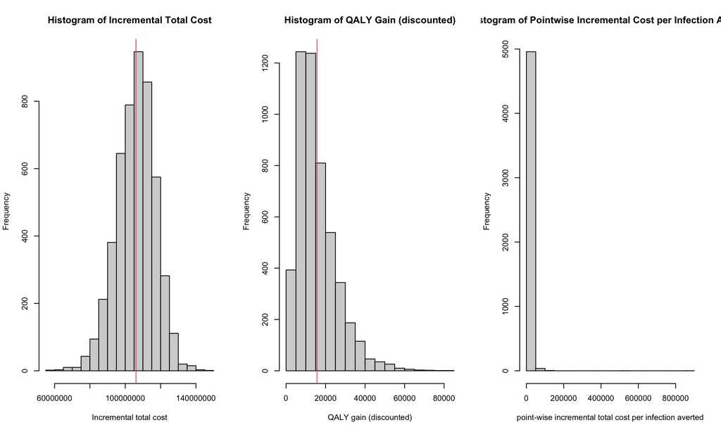

```r
mean(incr_total_cost / QALY_gained_disc) # mean of ratios
```

```
## [1] 10893.83
```

```r
mean(incr_total_cost) / mean(QALY_gained_disc) # ratio of means: ICER!!
```

```
## [1] 6761.249
```

```r
# Try WTP values bracketing the ICER to find where the expected INMB changes sign.
# At the ICER, the expected INMB is exactly 0. Values above the ICER yield positive
# expected INMB (intervention is cost-effective); values below yield negative INMB.
k = 8000 # above the ICER: expected INMB should be positive
mean(QALY_gained_disc * k - incr_total_cost)
```

```
## [1] 19431759
```

```r
# the INMB is not affected by the order of the operations
mean(QALY_gained_disc) * k - mean(incr_total_cost)
```

```
## [1] 19431759
```

```r
k = 6000 # below the ICER: expected INMB should be negative
mean(QALY_gained_disc * k - incr_total_cost)
```

```
## [1] -11941391
```

# Cost-effectiveness plane

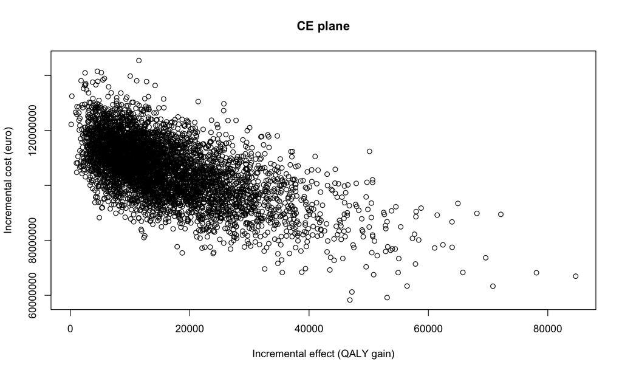

```r
# plot CE plane
plot(x = QALY_gained_disc,
     y = incr_total_cost,
     xlab = 'Incremental effect (QALY gain)',
     ylab = 'Incremental cost (euro)',
     main = 'CE plane')
```